# xv20220826_2_CCD_model

x.vergara

2022-09-28

# Script to generate figure #2 in the paper.

Fig. 2. CCDs of 89 DNA repair proteins. (A) Illustration of M- and N-synergy concepts. For chromatin feature – protein combinations with N-synergy (I in green) log2MMEJ:NHEJ scores increase as the chromatin feature levels increase. For combinations with M-synergy (II in brown) log2MMEJ:NHEJ scores decrease as the chromatin feature levels increase. For combinations with no synergy (III in black) log2MMEJ:NHEJ scores do not correlate with the individual chromatin features. (B) M-synergy example: linear fit (brown line) of RAD50 log2MMEJ:NHEJ scores with LMNB1 interaction. (C) No syn-ergy example: linear fit (black line) of MDC1 log2MMEJ:NHEJ scores with H2AFZ. (D) Heatmap of syn-ergy scores of all 89 proteins with significant CCDs. Proteins (columns) mentioned in the text are high-lighted in bold. Chromatin features (rows) are colored and ordered as in Fig. 1C. (E) Comparison of CCD effect sizes to global effect sizes of the proteins in (D). Global effect sizes are absolute values of global ∆log2MMEJ:NHEJ scores as calculated in Fig. 1B. CCD effect sizes are the predicted genome-wide dynamic range of ∆log2MMEJ:NHEJ values for each protein KO, as a function of variation in chromatin context (see Methods).

```r
knitr::opts_chunk$set(root.dir = '/home/x.vergara/XV_P3_ChromDSBScreen/xv_CRISPR_screen_figures/rmarkdown/xv20210920_paper_scripts/short_version/knit_html/')

StartTime <-Sys.time()
library(knitr)

# 8-digit Date tag:
Date <- substr(gsub("-","",Sys.time()),1,8)

#Change in.dir accordingly
in.dir <- "/home/x.vergara/XV_P3_ChromDSBScreen/xv_CRISPR_screen_figures/"

#Check if output contain datetag
saveRDS_proof <- function(object, file) {
  document_path <- rstudioapi::getSourceEditorContext()$path %>% str_split(pattern = "/") %>% unlist()
  document_name <- document_path[length(document_path)]
  sys_time <- Sys.time()
  if (grepl(Date, file) == T) {
    saveRDS(object, file)
    #write(c(document_name, as.character(sys_time),"Output", correct_file), file = paste0(in.dir,"log"), ncolumns = 4, sep = "\t", append = T)
  }
  else {
    print("Incorrect datetag!")
  }
}

#Read rds check through different versions
readRDS_proof <- function(path, pat) {
  full.path <- paste0(in.dir, path)
  document_path <- rstudioapi::getSourceEditorContext()$path %>% str_split(pattern = "/") %>% unlist()
  document_name <- document_path[length(document_path)]
  sys_time <- Sys.time()

  if(file.exists(full.path) == T){
    if(paste0(in.dir,path) != getwd()){
      setwd(paste0(in.dir, path))
  }
    file.list <- list.files(pattern = pat)
    correct_file <- str_sort(file.list, decreasing = T)[1]
    print(correct_file)
    readRDS(correct_file)
    #write(c(document_name,as.character(sys_time) ,"Input", correct_file), file = paste0(in.dir,"log"), ncolumns = 4, sep = "\t", append = T)

  }
  else{
  setwd(path)
  file.list <- list.files(pattern = pat)
  correct_file <- str_sort(file.list, decreasing = T)[1]
  print(correct_file)
  readRDS(correct_file)
  #write(c(document_name, as.character(sys_time),"Input", correct_file),file = paste0(in.dir,"log"), ncolumns = 4, sep = "\t", append = T)
  }
}
```

# Libraries

```r
# libraries:
library(tidyverse)
library(dendextend)
library(ggdendro)
library(grDevices)
library(pheatmap)
library(reshape2)
library(tibble)
library(ggpubr)
library(scales)
library(ggrepel)
library(ggdendro)
```

# Import data tables

```r
#setwd
setwd(in.dir)
# Individual data point (intermediate step)
step2.epistasis <- readRDS_proof("data/processed_data/CCD_analysis","log2_MMEJNHEJ_differentials_chromatin_KO")
```

```
## [1] "xv20220819_log2_MMEJNHEJ_differentials_chromatin_KO.rds"
```

```r
#DNA repair CCDs
table_S3_CCDs  <- readRDS_proof("data/processed_data","Table_S7")
```

```
## [1] "xv20220927_Table_S7_DR_screen_results.rds"
```

```r
# heatmap chromatin order
heatmap.chromatin.order <- c("HDAC3","LMNB1","late_replicating","H3K9me2","H3K9me3","HDAC1","EZH2","H3K27me3","CTCF","SMC3","m5C","HDAC2","POL2","POL2AS2","H3K36me3","TTseq","Dam","H3K79me2","H2AFZ","DNAse","H3K4me3","H4K5acK8ac","H3K4me1","H3K27ac","H3K4me2")
```

# Figure 2A: Mock examples

1. Illustration of M- and N-synergy concepts. For chromatin feature – protein combinations with N-synergy (I in green) log2MMEJ:NHEJ scores increase as the chromatin feature levels increase. For combinations with M-synergy (II in brown) log2MMEJ:NHEJ scores decrease as the chromatin feature levels increase. For combinations with no synergy (III in black) log2MMEJ:NHEJ scores do not correlate with the individual chromatin features.

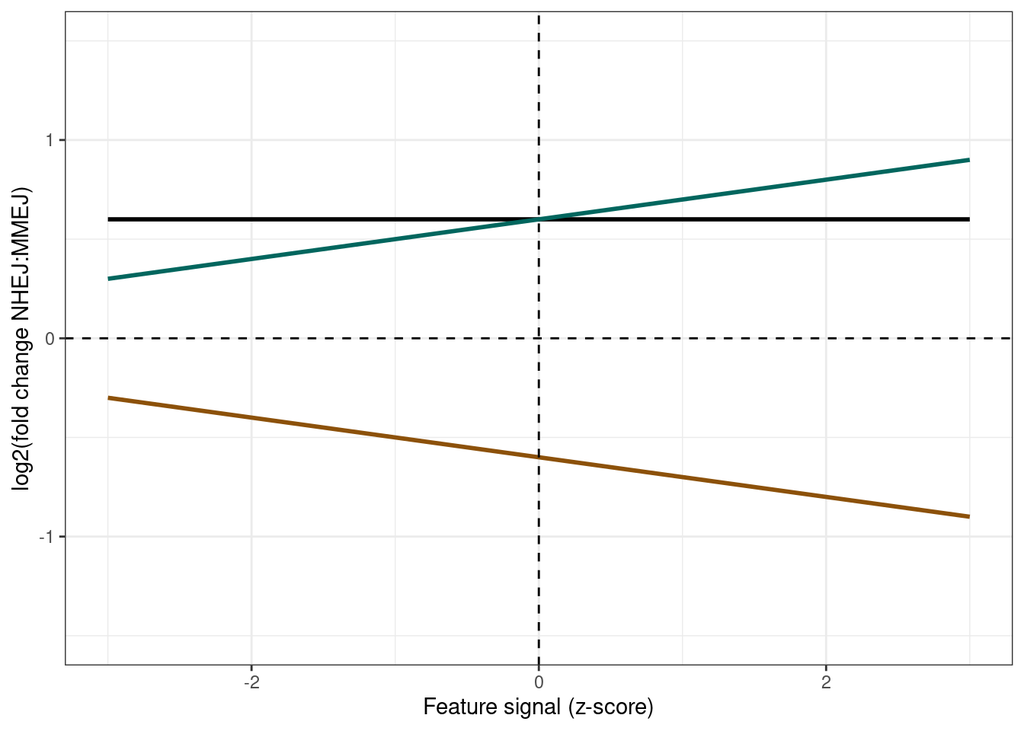

```r
#Create mock examples
mock.slopes <- tibble(z_score = seq(-3,3,0.25), A = z_score*0 + 0.6,B = z_score*0.1 +0.6, C = z_score*-0.1 - 0.6) %>% reshape2::melt(id.vars = "z_score")

#Plot mock examples
ggplot(mock.slopes, aes(z_score,value,color = variable)) + theme_bw() +
  geom_smooth() +
  geom_vline(xintercept = 0, linetype = 2) +
  geom_hline(yintercept = 0, linetype = 2) +
  ylab("log2(fold change NHEJ:MMEJ)") + xlab("Feature signal (z-score)") +
  theme(legend.position = "none") + coord_cartesian(ylim= c(-1.5,1.5)) + scale_color_manual(values = c("black","#01665e","#8c510a"))
```

# Figure 2B:

2. M-synergy example: linear fit (brown line) of RAD50 log2MMEJ:NHEJ scores with LMNB1 interaction.

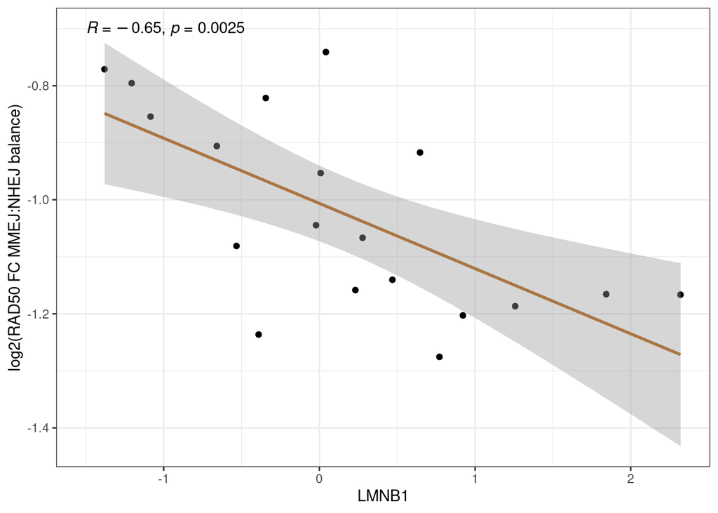

```r
# Plot RAD50 with LMNB1
ggplot(step2.epistasis %>%
         dplyr::filter(gene %in% c("RAD50")),
       aes(LMNB1,mean.log2foldchange)) +
  geom_point() +
  geom_smooth(aes(color = -0.114),method = "lm") +
  stat_cor(label.x = -1.5, label.y = -0.7) +
  scale_color_gradient2(low = "#8c510a",mid = "#f5f5f5", high = "#01665e", limits = c(-0.15,0.15)) +
  theme_bw() + ylab("log2(RAD50 FC MMEJ:NHEJ balance)") + theme(legend.position = "none")
```

#2C: No interaction C) No syn-ergy example: linear fit (black line) of MDC1 log2MMEJ:NHEJ scores with H2AFZ.

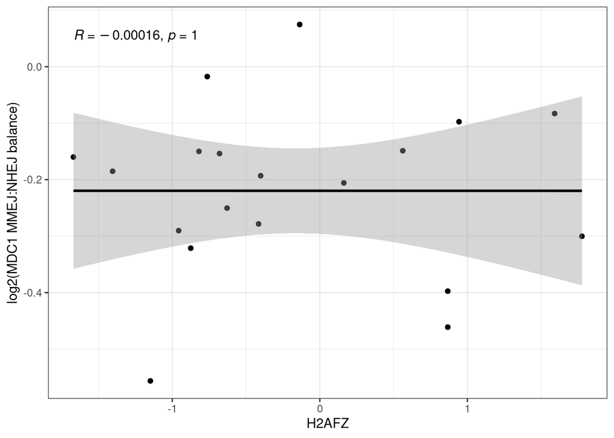

```r
# Plot MDC1 and H2AFZ
ggplot(step2.epistasis %>%
         filter(gene == "MDC1"),
       aes(H2AFZ,mean.log2foldchange)) +
  geom_point(color = "black") +
  geom_smooth(method = "lm", color = "black") +
  scale_color_gradient2(low = "#8c510a",mid = "#f5f5f5", high = "#01665e", limits = c(-0.15,0.15)) +
  stat_cor()+
  theme_bw() + ylab("log2(MDC1 MMEJ:NHEJ balance)")
```

# Figure 2D: Matrix for hits

4. Heatmap of syn-ergy scores of all 89 proteins with significant CCDs. Proteins (columns) mentioned in the text are high-lighted in bold. Chromatin features (rows) are colored and ordered as in Fig. 1C.

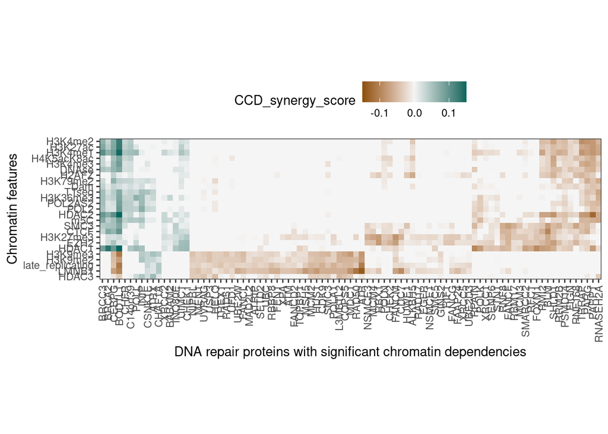

```r
# Separate data based on the significant IPRs that they have (based on z-score)
significant_proteins <- table_S3_CCDs %>% filter(CCD_model_p_adj < 0.05)

# dcaast with selected
slope.prot.features.dcast.hits <- significant_proteins %>% reshape2::dcast(gene ~ chrom_feature, value.var = "CCD_synergy_score") %>% column_to_rownames(var = "gene")

#Heatmap
signif_prots_heatmap <- pheatmap(t(slope.prot.features.dcast.hits), silent = T, clustering_method = "ward.D", cluster_rows = T, cutree_cols = 4)
signif_prots.gene.order <- rev(rownames(slope.prot.features.dcast.hits[signif_prots_heatmap$tree_col[["order"]],]))

# This are the effects

# heatmap: All heatmaps together
ggplot(significant_proteins) +
  geom_tile(aes(fct_relevel(gene,signif_prots.gene.order),fct_relevel(chrom_feature, heatmap.chromatin.order), fill = CCD_synergy_score)) +
  scale_fill_gradient2( low = "#8c510a",mid = "#f5f5f5", high = "#01665e",limits = c(-0.15,0.15), oob = squish, breaks = c(-0.1,0,0.1)) + theme_bw() + theme(axis.text.x = element_text(angle = 90, vjust = 0.5, hjust = 1), legend.position = "top") + coord_fixed(expand = F,ratio = 1) + xlab("DNA repair proteins with significant chromatin dependencies") + ylab("Chromatin features")
```

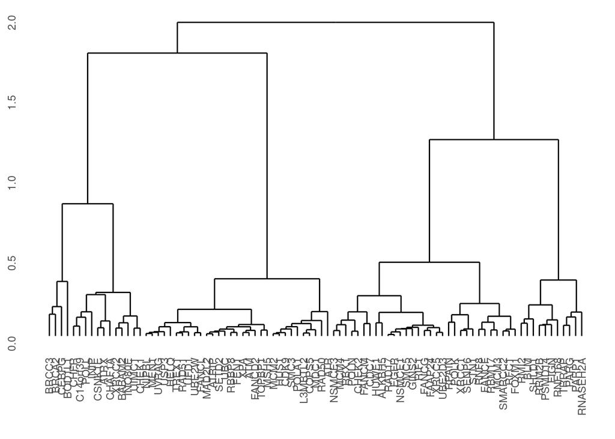

```r
# Dendrogram
ggdendrogram(rev(signif_prots_heatmap$tree_col))
```

5. Comparison of CCD effect sizes to global effect sizes of the proteins in (D). Global effect sizes are absolute values of global ∆log2MMEJ:NHEJ scores as calculated in Fig. 1B. CCD effect sizes are the predicted genome-wide dynamic range of ∆log2MMEJ:NHEJ values for each protein KO, as a function of variation in chromatin context (see Methods).

#Preparatory chunk: Compare CCDs vs. global effect

```r
##Filter max estimated FC
max_estimated_FC_CCD_gene <- table_S3_CCDs %>% dplyr::group_by(gene) %>% dplyr::summarise(max_CCD_estim_diff = max(abs(CCD_estim_diff)))

## Filter max(CCDs)
max_estimated_CCD_FC <- table_S3_CCDs %>% dplyr::select(gene,DR_effect_type,global_diff, CCD_model_p_adj, global_p_adj) %>% distinct() %>% left_join(max_estimated_FC_CCD_gene)
```

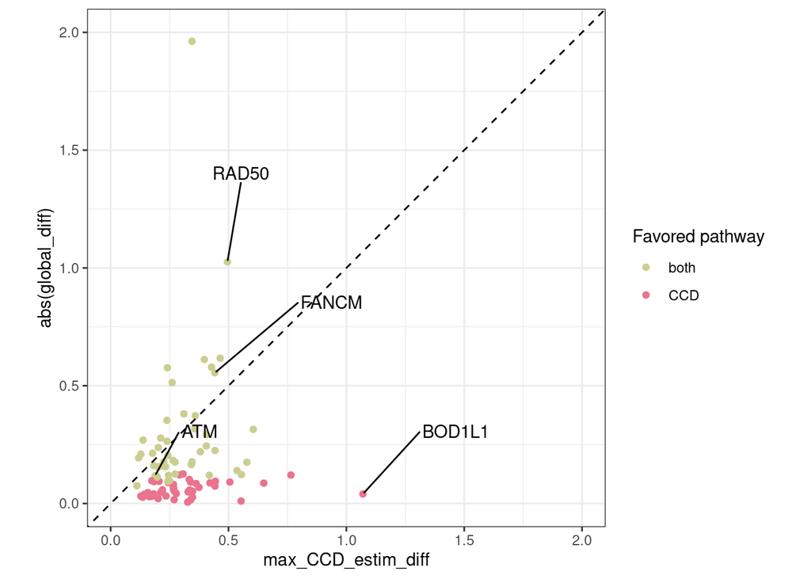

```r
#Highlight proteins
highlight_prots <- c("RAD50","FANCM","BOD1L1", "ATM")

#Plot
ggplot(max_estimated_CCD_FC %>% filter(DR_effect_type %in% c("CCD","both"))) +
  geom_point(aes(max_CCD_estim_diff, abs(global_diff), color = DR_effect_type)) +
  geom_text_repel(data = subset(max_estimated_CCD_FC, gene %in% highlight_prots), aes(max_CCD_estim_diff, abs(global_diff), label = gene), box.padding = 2.5) +
  scale_color_manual(values = c("#CBCE91","#EA738D")) + theme(legend.position = "top") + geom_abline(linetype = 2) + labs(color = "Favored pathway") + theme_bw() + coord_fixed(xlim = c(0,2), ylim = c(0,2))
```

#Output chunk